```python
print("hello world")
```

```
hello world
```

# Array

```python
import numpy as np
```

```python
x=[1,2,3,4] #this is list in python
print(x)
print(type(x)) #type function return the type of the variable

y=np.array([1,2,3,4]) #converting a list to an array

print(y)
print(type(y))
```

```
[1, 2, 3, 4]
<class 'list'>
[1 2 3 4]
<class 'numpy.ndarray'>
```

```python
l = [] # empty list
for i in range(1,4):
    element = int(input("enter element:"))
    l.append(element)
print(np.array(l))
```

```
[10 20 30]
```

```python
print(type(l))
```

```
<class 'list'>
```

```python
array_2 = np.array([[1,2,3,4],[5,6,7,8]]) # the number of element should be same in both list
```

```python
print(array_2)
```

```
[[1 2 3 4]
 [5 6 7 8]]
```

```python
print(type(array_2))
```

```
<class 'numpy.ndarray'>
```

```python
print(array_2.ndim) # .ndim gives the dimension of the array
```

```
2
```

```python
array_3 = np.array([[[1,2,3,4],[5,6,7,8],[9,10,11,12]]]) #this create 3-d array
```

```python
print(array_3.ndim)
```

```
3
```

```python
# now create a higher dimension array
arr = np.array([1,2,3,4],ndmin=10) # here i create an array of 10 dimension using ndmin
print(arr)
print(arr.ndim)
```

```
[[[[[[[[[[1 2 3 4]]]]]]]]]]
10
```

# create numpy array using functions

Create numpy array using Numpy function  Array filled with 0’s  Array filled with 1’s  Create an empty array  An array with a range of elements  Array diagonal element filled with 1’s  Create an array with values that are spaced linearly in a specified interval

#### zeros

```python
import numpy as np
ar_zero = np.zeros(4) # return an array of size 4 with element zeros
```

```python
print(ar_zero)
```

```
[0. 0. 0. 0.]
```

```python
arr_zero1 = np.zeros((3,4)) # it give the 3 rows and 4 columns as an array where all elements are filled with zero
```

```python
print(arr_zero1)
print(arr_zero1.ndim)
```

```
[[0. 0. 0. 0.]
 [0. 0. 0. 0.]
 [0. 0. 0. 0.]]
2
```

#### ones

```python
arr_one = np.ones(4) #it create an array with length 4 all element filled with 1
print(arr_one)
```

```
[1. 1. 1. 1.]
```

```python
arr_one1 = np.ones((3,4))
print(arr_one1)
```

```
[[1. 1. 1. 1.]
 [1. 1. 1. 1.]
 [1. 1. 1. 1.]]
```

#### empty

```python
arr = np.empty(4) # it create an empty array with garbage value in our case it give all element 1
print(arr)
```

```
[1. 1. 1. 1.]
```

```python
arr1 = np.empty((3,4))
print(arr1)
```

```
[[1. 1. 1. 1.]
 [1. 1. 1. 1.]
 [1. 1. 1. 1.]]
```

#### range

```python
arr_range = np.arange(4) #this gives an array in a range here 0 to 3
print(arr_range)
```

```
[0 1 2 3]
```

```python
arr1= np.arange(4)*3 #this return a list of array element from 0 to 3 but with multiplication by 3
print(arr1)
```

```
[0 3 6 9]
```

#### diagonal

```python
arr_dia = np.eye(3) # it gives a diagonal matrix of array where diagonal elements filled with 1
print(arr_dia)
```

```
[[1. 0. 0.]
 [0. 1. 0.]
 [0. 0. 1.]]
```

```python
arr_dia_1 = np.eye(3,4)
print(arr_dia_1)
```

```
[[1. 0. 0. 0.]
 [0. 1. 0. 0.]
 [0. 0. 1. 0.]]
```

#### linspace

```python
arr_linspace = np.linspace(0,20,num=5) # it gives the array of equal spacing in a given rang here it gives 5 element in range 0 to 20 with equal spacing
print(arr_linspace)
```

```
[ 0.  5. 10. 15. 20.]
```

```python
arr_linspace_1 = np.linspace(0,10,num=5)
print(arr_linspace_1)
```

```
[ 0.   2.5  5.   7.5 10. ]
```

# create numpy array with random number

rand() : the function is used to generate a random value b/w 0 to 1 randn() : the function is used to generate a random value close to zero. ranf() : the function for doing random sampling in numpy. It returns an array of specified shape and fills it with random floats in the half-open interval [0.0 ,1.0) randint() : the function is used to generate a random number between a given range

```python
import numpy as np
```

#### rand()

```python
var = np.random.rand(4) # it generate random number b/w 0 and 1 here value 4 is used for number of elements
print(var)
```

```
[0.03574159 0.59699312 0.76954561 0.43759489]
```

```python
var_mat = np.random.rand(3,4)
print(var_mat)
```

```
[[0.38573055 0.31420164 0.48829382 0.81200059]
 [0.18871894 0.83926189 0.19742132 0.12415764]
 [0.71876647 0.22044063 0.6657041  0.52285742]]
```

#### randn()

```python
var2 = np.random.randn(10) # it gives element as normal distribution
print(var2)
```

```
[-0.77154902 -0.38505908  2.18738514 -0.60514131 -0.31204387  0.44711071
 -0.4574108   0.96164454  1.82806441  0.63899948]
```

#### ranf()

```python
var3 = np.random.ranf(5) # it gives the value b/w 0 and 1(exclusive) but eache number b/w 0 and 1 has equal probability to come it is totaly differnt from randn()
print(var3)
```

```
[0.71463985 0.37744243 0.52172839 0.69083802 0.29640866]
```

#### randint()

```python
var4 = np.random.randint(5,20,4) # this gives the random number b/w 5 to 20 and 4 is taken as the number of element
print(var4)
```

```
[ 7  6  6 11]
```

# data types in numpy array

[figure not shown]

```python
import numpy as np
var = np.array([1,2,3,4])
print("Data type : ",var.dtype) # .dtype returns the type of data
```

```
Data type :  int64
```

```python
var1 = np.array([1.0,2.0,3.0,4.0])
print("Data type : ",var1.dtype)
```

```
Data type :  float64
```

```python
var2 = np.array(["a","b","c","d"])
print("Data type : ",var2.dtype)
```

```
Data type :  <U1
```

```python
var3 = np.array(["a","b","c","d",1,2,3,4])
print("Data type : ",var3.dtype)
```

```
Data type :  <U21
```

🧠 Step 1: NumPy Rule (Very Important)

NumPy arrays:

✅ Must have a single data type ❌ Cannot store mixed types like Python lists

So when you give:

["a","b","c","d",1,2,3,4]

This is:

Strings

Integers

NumPy must convert everything into one common type.

👉 Unicode string

So it converts numbers into strings internally:

["a","b","c","d","1","2","3","4"]

Now everything becomes string.

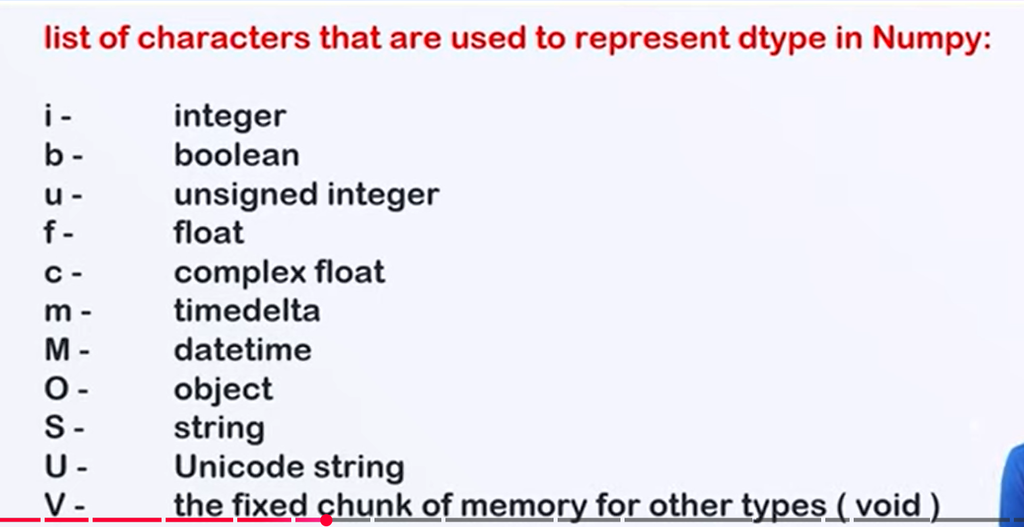

# convert data type

✅ Method 1: Using astype() (Most Important)

This is the most used method.

Example 1: Integer → Float

```python
import numpy as np

arr = np.array([1, 2, 3, 4])
print(arr.dtype)

new_arr = arr.astype(float)
print(new_arr.dtype)
```

```
int64
float64
```

```python
# Example 2 : -
arr = np.array([1.5, 2.7, 3.9])
new_arr = arr.astype(int)
print(new_arr)
```

```
[1 2 3]
```

```python
# Example 3 :-
```

```python
arr = np.array([1, 2, 3])
new_arr = arr.astype(str)
print(new_arr.dtype)
```

```
<U21
```

✅ Method 2: Define dtype at Creation Time

Better practice in ML:

```python
arr = np.array([1,2,3], dtype=float)
print(arr.dtype)
```

```
float64
```

```python
arr = np.array([1,2,3,4])
print(arr.dtype)
```

```
int64
```

```python
arr = np.array([1,2,3,4],dtype = np.int8)
print(arr.dtype)
```

```
int8
```

✅ Method 3:

```python
x = np.array([1,2,3,4])
new = np.float32(x)
print("Data type : ",x.dtype)
print("Data type : ",new.dtype)
```

```
Data type :  int64
Data type :  float32
```

# shaping and reshaping in Numpy arrays

## 🔥 Shape and Reshape in NumPy Array

In NumPy, **shape** and **reshape** are extremely important — especially for ML, deep learning, and image processing.

# 🧠 1️⃣ What is `shape`?

`shape` tells you:

> How many rows and columns (dimensions) an array has.

## ✅ Example 1: 1D Array

```
import numpy as np

arr = np.array([1,2,3,4])
print(arr.shape)
```

Output:

```
(4,)
```

Meaning:

- 4 elements
- 1 dimension

## ✅ Example 2: 2D Array (Matrix)

```
arr = np.array([[1,2,3],
                [4,5,6]])
print(arr.shape)
```

Output:

```
(2, 3)
```

Meaning:

- 2 rows
- 3 columns

Format:

```
(rows, columns)
```

## ✅ Example 3: 3D Array

```
arr = np.array([[[1,2],[3,4]],
                [[5,6],[7,8]]])
print(arr.shape)
```

Output:

```
(2, 2, 2)
```

Meaning:

- 2 blocks
- 2 rows
- 2 columns

# 🔥 2️⃣ What is `reshape()`?

`reshape()` changes the structure of array without changing data.

Important Rule:

> Total elements must remain same.

## ✅ Example 1: 1D → 2D

```
arr = np.array([1,2,3,4,5,6])
new_arr = arr.reshape(2,3)
print(new_arr)
```

Output:

```
[[1 2 3]
 [4 5 6]]
```

Here:

- Original elements = 6
- New shape = 2 × 3 = 6 ✅

## ❌ Invalid Example

```
arr.reshape(4,3)
```

Error ❌ Because: 4 × 3 = 12 But original elements = 6

# 🔥 3️⃣ Using `-1` (Very Important 🔥🔥🔥)

`-1` means:

> NumPy automatically calculate this dimension.

Example:

```
arr = np.array([1,2,3,4,5,6])

new_arr = arr.reshape(2, -1)
print(new_arr)
```

Output:

```
[[1 2 3]
 [4 5 6]]
```

NumPy automatically calculated: 6 elements ÷ 2 rows = 3 columns

# 🔥 ML Practical Example

In Machine Learning:

Suppose dataset:

- 100 samples
- 28 × 28 image

You reshape like:

```
data = data.reshape(100, 28, 28)
```

For neural network:

```
data = data.reshape(100, -1)
```

Flattening image.

# 🎯 Difference Between Shape and Reshape

| Feature | shape | reshape() |
| --- | --- | --- |
| Purpose | Check dimensions | Change dimensions |
| Type | Attribute | Function |
| Modifies data? | No | Returns new array |

# 🚀 Bonus: `ndim` and `size`

```
print(arr.ndim)   # Number of dimensions
print(arr.size)   # Total elements
```

Very useful in ML debugging.